# An Introduction (to an Introduction) to Time Series

- by: Jaume Palmer (JAPR) | September 2024

## Time Series

- 1. Data with a time index.
- 2. An attempt at measuring a dynamical system.

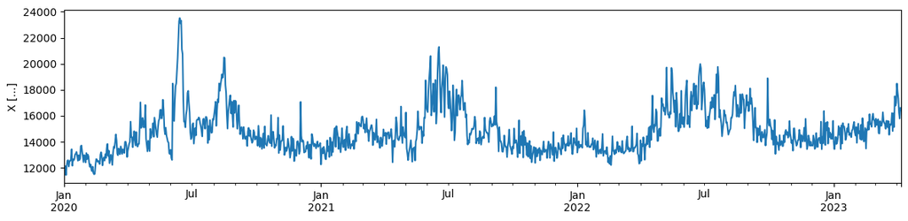

```python
plot_timeseries(train, target_label, "X [...]")
```

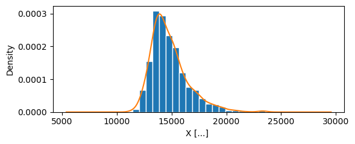

```python
fig, ax = plt.subplots(1, 1, figsize=(6, 2.5))
plot_distribution(train, target_label, "X [...]", ax=ax)
```

## Case study: Aggregated water consumption

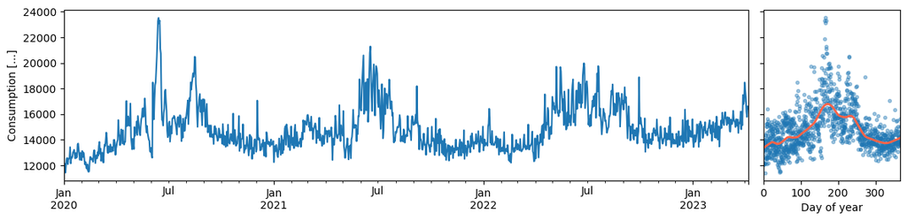

```python
plot_timeseries_and_pattern(train, target_label, "Consumption [...]")
```

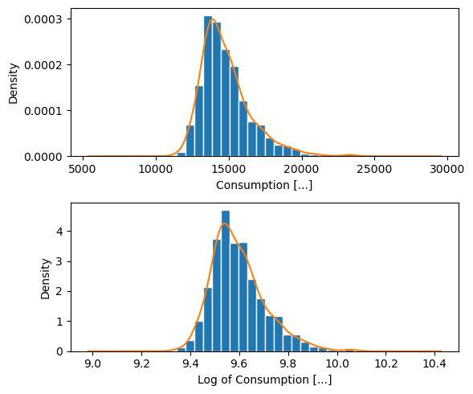

```python
new_target = f"log_{target_label}"
train[new_target] = np.log(train[target_label])
compare_distributions(train, target_label, new_target, "Consumption [...]", "Log of Consumption [...]")
```

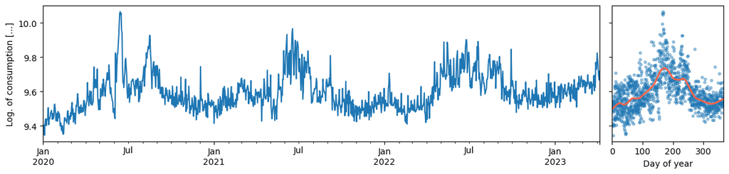

```python
plot_timeseries_and_pattern(train, new_target, "Log. of consumption [...]")
```

Can we describe this time series with parameters that do not change in time?

## Stationarity

A characteristic of a time series that guarantees that its statistical properties do not change over time.

The consumption is clearly **non-stationary**

- It shows (at least) two distinct behaviours → this suggests a *seasonal* pattern

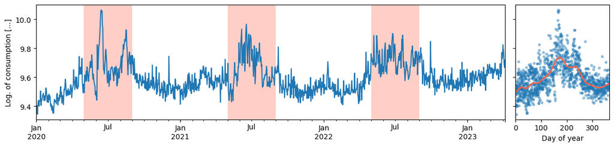

```python
summer_spans = [(pd.Timestamp(f"05-01-{year}"), pd.Timestamp(f"09-01-{year}")) for year in [2020, 2021, 2022]]
plot_timeseries_and_pattern(train, new_target, "Log. of consumption [...]", spans=summer_spans)
```

- What about the yearly difference?

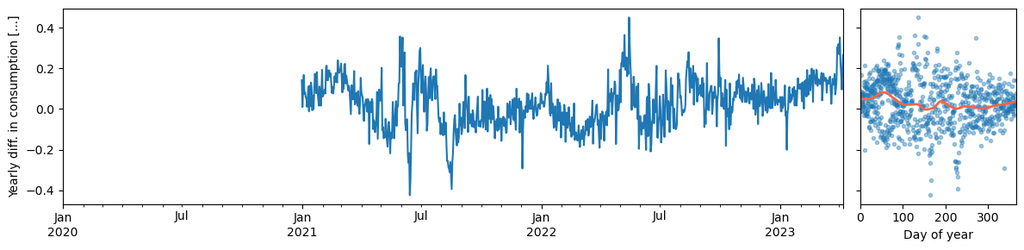

```python
newer_target = f"d365_{new_target}"
train[newer_target] = train[new_target].diff(365)
plot_timeseries_and_pattern(train, newer_target, "Yearly diff. in consumption [...]")
```

A certain *trend* is observed still.

- And the daily difference?

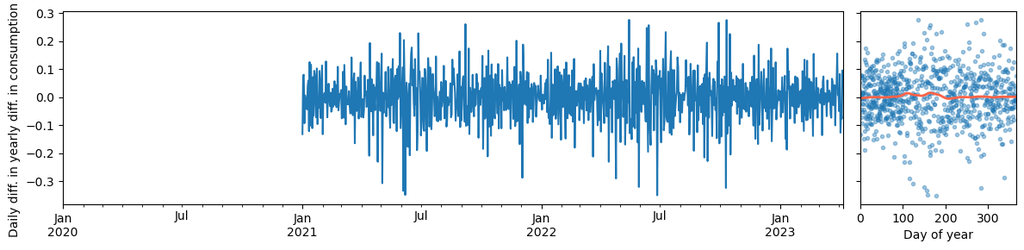

```python
even_newer_target = f"d365_d1_{target_label}"
train[even_newer_target] = train[newer_target].diff(1)
plot_timeseries_and_pattern(train, even_newer_target, "Daily diff. in yearly diff. in consumption [...]")
```

If this sounds too arbitrary...

you can use the *Augmented Dickey-Fuller* test:

```python
adf_results.round(3)
```

|  | metric | p-value |
| --- | --- | --- |
| Log transformation | -3.166 | 0.022 |
| Yearly diff. | -4.290 | 0.000 |
| Yearly & daily diff. | -9.814 | 0.000 |

## Modelling with ARIMA

A family of models/methods that aims at expressing a time series as a combination of the following components:

AR (*Auto-Regressive*)  
☑ I (*Integrated*)  
MA (*Moving Average*)

**Assumptions:**

- Everything is linear
- Everything is Gaussian

### But first: Correlation

It is a measure of how (linearly) related two random variables are.

```python
y1 = np.random.normal(0, 1, n)
y2 = 2 * y1 + np.random.normal(1, 1, n)
y3 = 0.2 * y1 + np.random.normal(0, 1, n)
```

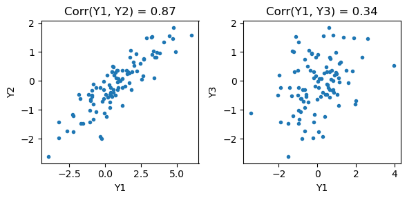

```python
plot_rvs(y1, y2, y3)
```

**But** remember that I can have random variables that are time-indexed.

```python
lag = 10
y4 = y1[lag:] + np.random.normal(0, 0.3, n - lag)
```

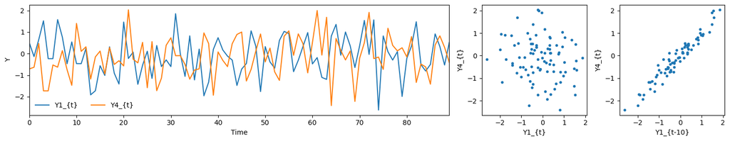

```python
plot_rv_with_lags(y1, y4, lag)
```

In a time series context, past values of a random variable can be considered another random variable

- Are present values of a series (cor)related to its past values?
  - Then we say that variable is *autocorrelated (e.g. the _Random Walk*: $Y_t = Y_{t-1} + \epsilon_{t}$)

### ...back to modelling

We can check if the **consumption is autocorrelated** by investigating the *ACF* and *PACF*

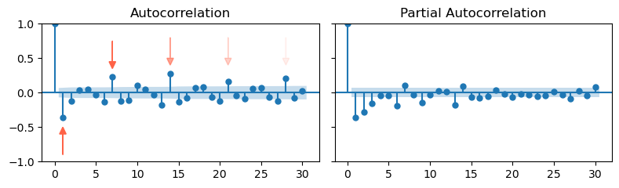

```python
fig, axes = plt.subplots(1, 2, sharey=True, figsize=(8, 2.5))
plot_acf(target.values, ax=axes[0]), plot_pacf(target.values, ax=axes[1])
add_arrows(axes[0])
_, _ = plt.tight_layout(), plt.show()
```

In a nutshell, you need to look at the peaks:

- There is a clear peak at lag 1 (and at lag 7)

☑ AR (*Auto-Regressive*) → $Y_t = \overbrace{\theta_1 Y_{t-1} + \cdots + \theta_i Y_{t-i}}^{p} + \epsilon_{t}$  
☑ MA (*Moving Average*) → $Y_t = \epsilon_{t} + \overbrace{\theta_1\epsilon_{t-1} + \cdots + \theta_i\epsilon_{t-i}}^{q}$

```python
p, d, q = (1, 0, 1)  # Based on ACF and PACF
mod = ARIMA(endog=target, order=(p, d, q), freq="D", trend="n")
res = mod.fit()
show_results_as_html(res, 0)
```

SARIMAX Results

| Dep. Variable: | d365_d1_real_consumption | No. Observations: | 827 |
| --- | --- | --- | --- |
| Model: | ARIMA(1, 0, 1) | Log Likelihood | 920.073 |
| Date: | Wed, 18 Sep 2024 | AIC | -1834.146 |
| Time: | 16:11:10 | BIC | -1819.993 |
| Sample: | 01-01-2021 | HQIC | -1828.718 |
|  | - 04-07-2023 |  |  |
| Covariance Type: | opg |  |  |

(!) *AIC* and *BIC* are statistical tests to evaluate the performance of the model

Ultimately, the model is evaluated checking whether its **residuals** behave like independent and identically distributed **Gaussian white noise**.

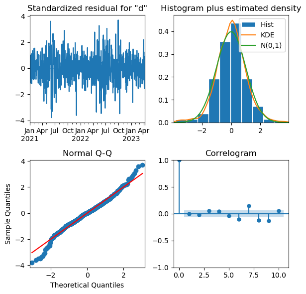

```python
diagnostics = res.plot_diagnostics(figsize=(6, 6))
plt.tight_layout()
```

What is happening in the previous correlogram at lag 7?

```python
exog = convert_day_of_week_into_exog(target.index)
mod = sm.tsa.arima.ARIMA(endog=target, exog=exog, order=(p, d, q), freq="D", trend="n")
res = mod.fit()
show_results_as_html(res, 0)
```

SARIMAX Results

| Dep. Variable: | d365_d1_real_consumption | No. Observations: | 827 |
| --- | --- | --- | --- |
| Model: | ARIMA(1, 0, 1) | Log Likelihood | 995.385 |
| Date: | Wed, 18 Sep 2024 | AIC | -1970.770 |
| Time: | 16:11:13 | BIC | -1923.592 |
| Sample: | 01-01-2021 | HQIC | -1952.675 |
|  | - 04-07-2023 |  |  |
| Covariance Type: | opg |  |  |

Since everything is linear, we can simply add **exogenous inputs** to the previous model.

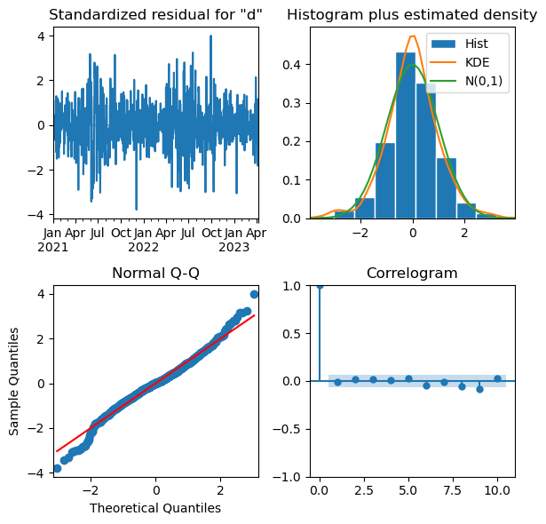

```python
diagnostics = res.plot_diagnostics(figsize=(6, 6))
plt.tight_layout()
```

#### **A book-keeping exercise**

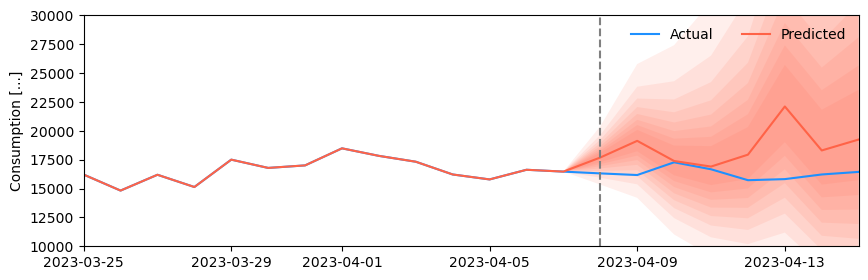

```python
plot_results()
```

It's **probabilistic**! (... yet, a bit underwhelming)

- Options for improvement:
  - Seasonal pattern is not very consistent
  - Do we have too much noise in the training sample?
  - Are we missing other external forcings? (e.g. temperature)

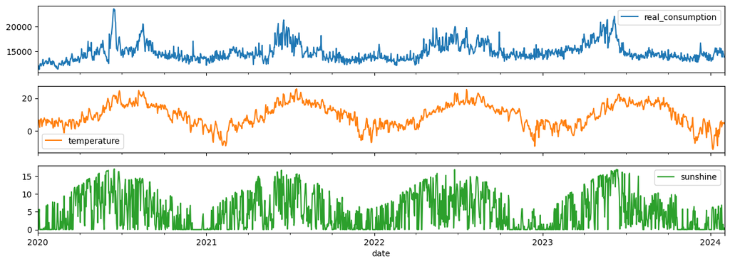

```python
# Some additional variables that we could consider adding
data[["real_consumption", "temperature", "sunshine"]].plot(subplots=True, figsize=(15, 5))
plt.show()
```

## Workflow summary

[figure not shown]

## Conclusion

- "Everything" is a random variable
- Statistical models are a solid first step
  - Lightweight and robust (and probabilistic)
- Much of this workflow are transferable to other models
  - E.g. adding lagged variables as features
  - E.g. using differences as target
- The methods are modular and transparent, helping with interpretability
- Statistical methods allow quantifying modelling success

### **Thank you**

**Concepts worth investigating further**

- Main python package used in this talk: `statsmodels`
  - Honorable mentions: `darts`, `AutoARIMA`
- Relevant concepts:
  - **Power transformations:** Box-Cox transformation
  - **Time series decomposition**
  - **Stationarity:** Augmented Dickey-Fuller test
  - **Autocorrelation:** ACF, PACF
  - **Model quality evaluation:** AIC, BIC